# stretch_shift_corresponding_pnts

## stretch_shift_corresponding_pnts

#### Question

1. Curve $y=f[x]$ contains points $(6,5)$ and $(12,2)$ and $(18,8)$, as shown on the $x$-$y$ plane below.

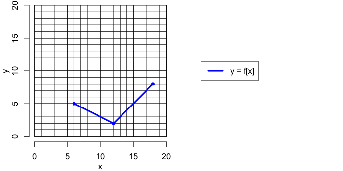

   In other words:
   $$f[6]=5$$
   $$f[12]=2$$
   $$f[18]=8$$

   Let function $g$ be a transformation of function $f$, as defined by the equation below:

   $$g[x]~=~2\cdot f{\left[3\cdot\left(x+2\right)\right]}-4$$

   Find the three corresponding points of curve $y=g[x]$.

   | $x$ | $g[x]$ |
   | --- | --- |

#### Solution

#### Question

2. Curve $y=f[x]$ contains points $(0,6)$ and $(3,12)$ and $(12,16)$, as shown on the $x$-$y$ plane below.

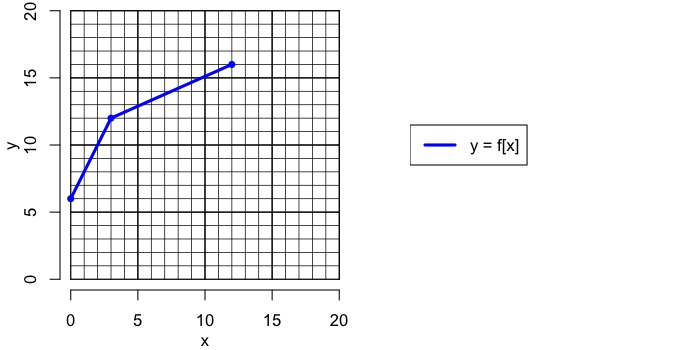

   In other words:
   $$f[0]=6$$
   $$f[3]=12$$
   $$f[12]=16$$

   Let function $g$ be a transformation of function $f$, as defined by the equation below:

   $$g[x]~=~\frac{f{\left[3\cdot\left(x-1\right)\right]}+2}{2}$$

   Find the three corresponding points of curve $y=g[x]$.

   | $x$ | $g[x]$ |
   | --- | --- |

#### Solution

#### Question

3. Curve $y=f[x]$ contains points $(4,18)$ and $(8,3)$ and $(12,9)$, as shown on the $x$-$y$ plane below.

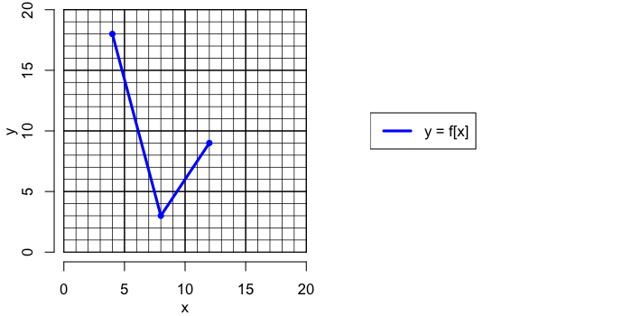

   In other words:
   $$f[4]=18$$
   $$f[8]=3$$
   $$f[12]=9$$

   Let function $g$ be a transformation of function $f$, as defined by the equation below:

   $$g[x]~=~\frac{f{\left[2\cdot\left(x+1\right)\right]}-3}{3}$$

   Find the three corresponding points of curve $y=g[x]$.

   | $x$ | $g[x]$ |
   | --- | --- |

#### Solution

#### Question

4. Curve $y=f[x]$ contains points $(4,12)$ and $(6,0)$ and $(10,9)$, as shown on the $x$-$y$ plane below.

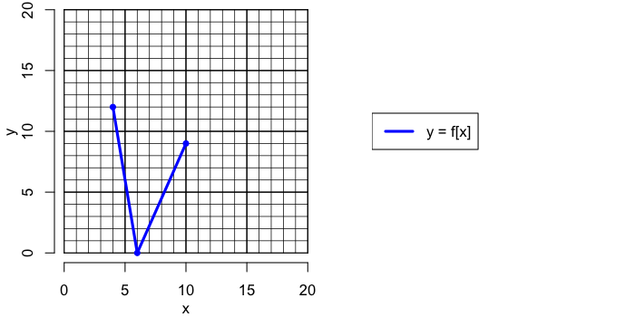

   In other words:
   $$f[4]=12$$
   $$f[6]=0$$
   $$f[10]=9$$

   Let function $g$ be a transformation of function $f$, as defined by the equation below:

   $$g[x]~=~\frac{f{\left[\frac{x+4}{2}\right]}}{3}+3$$

   Find the three corresponding points of curve $y=g[x]$.

   | $x$ | $g[x]$ |
   | --- | --- |

#### Solution

#### Question

5. Curve $y=f[x]$ contains points $(5,6)$ and $(8,8)$ and $(11,4)$, as shown on the $x$-$y$ plane below.

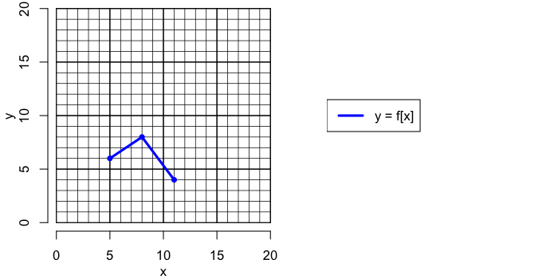

   In other words:
   $$f[5]=6$$
   $$f[8]=8$$
   $$f[11]=4$$

   Let function $g$ be a transformation of function $f$, as defined by the equation below:

   $$g[x]~=~2\cdot f{\left[\frac{x}{3}+5\right]}-4$$

   Find the three corresponding points of curve $y=g[x]$.

   | $x$ | $g[x]$ |
   | --- | --- |

#### Solution

#### Question

6. Curve $y=f[x]$ contains points $(4,2)$ and $(6,6)$ and $(8,8)$, as shown on the $x$-$y$ plane below.

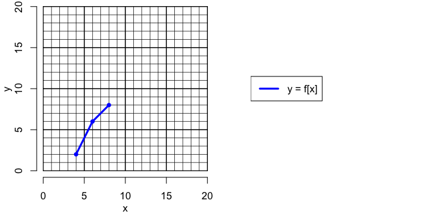

   In other words:
   $$f[4]=2$$
   $$f[6]=6$$
   $$f[8]=8$$

   Let function $g$ be a transformation of function $f$, as defined by the equation below:

   $$g[x]~=~2\cdot\left(f{\left[\frac{x+6}{3}\right]}+2\right)$$

   Find the three corresponding points of curve $y=g[x]$.

   | $x$ | $g[x]$ |
   | --- | --- |

#### Solution

#### Question

7. Curve $y=f[x]$ contains points $(0,18)$ and $(9,6)$ and $(18,0)$, as shown on the $x$-$y$ plane below.

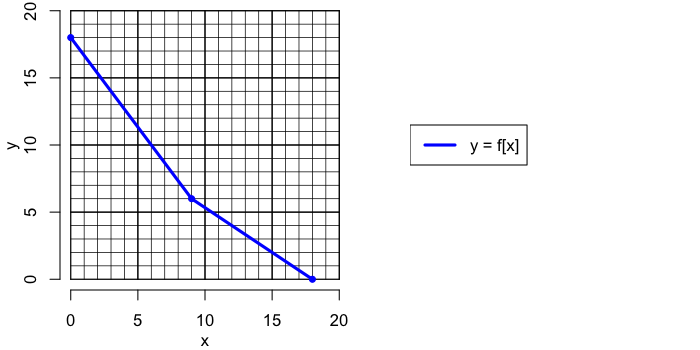

   In other words:
   $$f[0]=18$$
   $$f[9]=6$$
   $$f[18]=0$$

   Let function $g$ be a transformation of function $f$, as defined by the equation below:

   $$g[x]~=~\frac{f{\left[3\cdot x-3\right]}+6}{2}$$

   Find the three corresponding points of curve $y=g[x]$.

   | $x$ | $g[x]$ |
   | --- | --- |

#### Solution

#### Question

8. Curve $y=f[x]$ contains points $(6,4)$ and $(12,7)$ and $(18,1)$, as shown on the $x$-$y$ plane below.

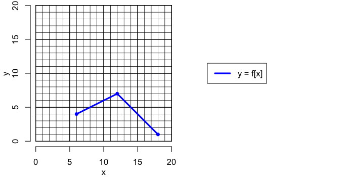

   In other words:
   $$f[6]=4$$
   $$f[12]=7$$
   $$f[18]=1$$

   Let function $g$ be a transformation of function $f$, as defined by the equation below:

   $$g[x]~=~2\cdot\left(f{\left[3\cdot x+3\right]}+2\right)$$

   Find the three corresponding points of curve $y=g[x]$.

   | $x$ | $g[x]$ |
   | --- | --- |

#### Solution

#### Question

9. Curve $y=f[x]$ contains points $(0,20)$ and $(12,4)$ and $(18,0)$, as shown on the $x$-$y$ plane below.

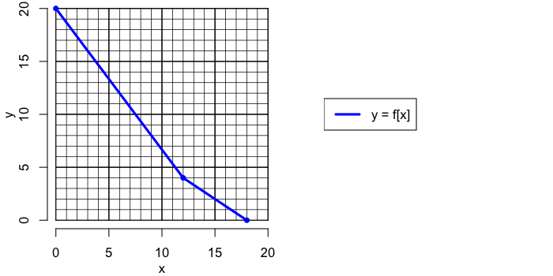

   In other words:
   $$f[0]=20$$
   $$f[12]=4$$
   $$f[18]=0$$

   Let function $g$ be a transformation of function $f$, as defined by the equation below:

   $$g[x]~=~\frac{f{\left[3\cdot\left(x-5\right)\right]}+4}{2}$$

   Find the three corresponding points of curve $y=g[x]$.

   | $x$ | $g[x]$ |
   | --- | --- |

#### Solution

#### Question

10. Curve $y=f[x]$ contains points $(3,1)$ and $(9,5)$ and $(10,3)$, as shown on the $x$-$y$ plane below.

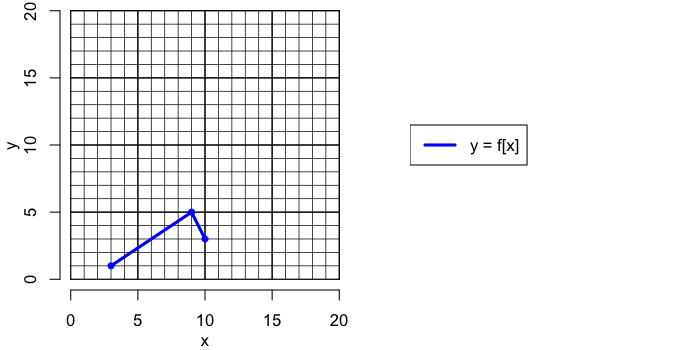

    In other words:
    $$f[3]=1$$
    $$f[9]=5$$
    $$f[10]=3$$

    Let function $g$ be a transformation of function $f$, as defined by the equation below:

    $$g[x]~=~3\cdot\left(f{\left[\frac{x+2}{2}\right]}+1\right)$$

    Find the three corresponding points of curve $y=g[x]$.

    | $x$ | $g[x]$ |
    | --- | --- |

#### Solution

#### Question

11. Curve $y=f[x]$ contains points $(3,10)$ and $(4,16)$ and $(5,14)$, as shown on the $x$-$y$ plane below.

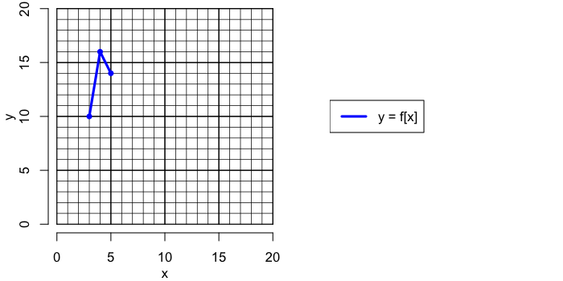

    In other words:
    $$f[3]=10$$
    $$f[4]=16$$
    $$f[5]=14$$

    Let function $g$ be a transformation of function $f$, as defined by the equation below:

    $$g[x]~=~\frac{f{\left[\frac{x}{3}+3\right]}}{2}-1$$

    Find the three corresponding points of curve $y=g[x]$.

    | $x$ | $g[x]$ |
    | --- | --- |

#### Solution

#### Question

12. Curve $y=f[x]$ contains points $(4,3)$ and $(6,15)$ and $(8,18)$, as shown on the $x$-$y$ plane below.

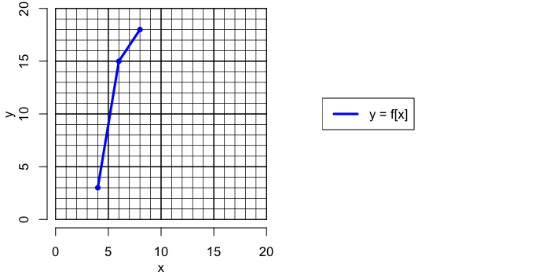

    In other words:
    $$f[4]=3$$
    $$f[6]=15$$
    $$f[8]=18$$

    Let function $g$ be a transformation of function $f$, as defined by the equation below:

    $$g[x]~=~\frac{f{\left[\frac{x}{2}-2\right]}+3}{3}$$

    Find the three corresponding points of curve $y=g[x]$.

    | $x$ | $g[x]$ |
    | --- | --- |

#### Solution